# Session 01: The Broken Toy

**Companion notebook to the Session 01 lecture.**

Run every cell in order. The plots are the lesson.

```python
import numpy as np
import matplotlib.pyplot as plt

%matplotlib inline
np.random.seed(0)

plt.rcParams['figure.figsize'] = (7, 6)
plt.rcParams['figure.dpi'] = 100

COLOR_A = '#1B7F79'   # teal — positive bending
COLOR_B = '#C2571A'   # amber — other class
COLOR_LINE = '#1B2A4A' # navy — ideal boundary
```

# Section 1 — Generating the measurements

A cantilever beam has two strain gauges at the same cross-section, one on the top surface and one on the bottom. Two independent physical causes contribute to the readings:

- **Axial strain** $\varepsilon_a$: tension or compression. Same sign on both surfaces.
- **Bending strain** $\varepsilon_b$: bending. Opposite signs on top and bottom.

The raw readings are mixtures of the two, plus measurement noise.

```python
rng = np.random.default_rng(0)
n = 300

# Two independent physical causes, each standard normal
axial   = rng.normal(0, 1.0, n)   # ε_a
bending = rng.normal(0, 1.0, n)   # ε_b

# Measurement noise (small)
noise = 0.05 * rng.normal(0, 1, (n, 2))

# Raw sensor readings — each mixes both causes
top    = axial + bending + noise[:, 0]   # ε_top
bottom = axial - bending + noise[:, 1]   # ε_bottom
X_raw  = np.c_[top, bottom]

print(f"Number of samples: {n}")
print(f"Top strain:    mean={top.mean():+.3f}  std={top.std():.3f}  range=[{top.min():+.2f}, {top.max():+.2f}]")
print(f"Bottom strain: mean={bottom.mean():+.3f}  std={bottom.std():.3f}  range=[{bottom.min():+.2f}, {bottom.max():+.2f}]")
print(f"Axial strain:  mean={axial.mean():+.3f}  std={axial.std():.3f}")
print(f"Bending strain: mean={bending.mean():+.3f}  std={bending.std():.3f}")
```

```
Number of samples: 300
Top strain:    mean=-0.048  std=1.440  range=[-5.88, +3.50]
Bottom strain: mean=-0.028  std=1.385  range=[-3.64, +3.92]
Axial strain:  mean=-0.036  std=1.018
Bending strain: mean=-0.010  std=0.975
```

```python
# Class label: is the beam bending upward?
y = (bending > 0).astype(int)

print(f"Class 0 (other):          {np.sum(y == 0)} samples")
print(f"Class 1 (positive bend):  {np.sum(y == 1)} samples")
```

```
Class 0 (other):          153 samples
Class 1 (positive bend):  147 samples
```

```python
from sklearn.tree import DecisionTreeClassifier
from sklearn.model_selection import cross_val_score

clf = DecisionTreeClassifier(max_depth=3, random_state=0)

score_raw  = cross_val_score(clf, X_raw,  y, cv=5).mean()

print(f"Raw coordinates:      {score_raw:.3f}")
```

```
Raw coordinates:      0.867
```

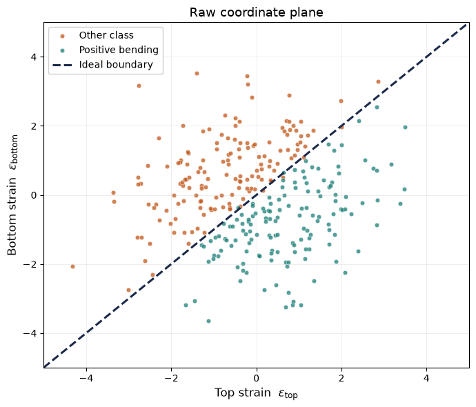

```python
# Visualize the raw coordinate plane
fig, ax = plt.subplots()

for cls, color, label in [(0, COLOR_B, 'Other class'),
                          (1, COLOR_A, 'Positive bending')]:
    mask = (y == cls)
    ax.scatter(top[mask], bottom[mask], c=color, s=22,
               alpha=0.75, label=label, edgecolors='white', linewidths=0.4)

# Ideal boundary: ε_top = ε_bottom, i.e. the line y = x
lim = 5
ax.plot([-lim, lim], [-lim, lim], '--', color=COLOR_LINE,
        linewidth=2.2, label='Ideal boundary')

ax.set_xlim(-lim, lim)
ax.set_ylim(-lim, lim)
ax.set_xlabel(r'Top strain  $\varepsilon_{\mathrm{top}}$', fontsize=12)
ax.set_ylabel(r'Bottom strain  $\varepsilon_{\mathrm{bottom}}$', fontsize=12)
ax.set_title('Raw coordinate plane', fontsize=13)
ax.legend(loc='upper left', framealpha=0.9)
ax.grid(alpha=0.3)
plt.tight_layout()
plt.show()
```

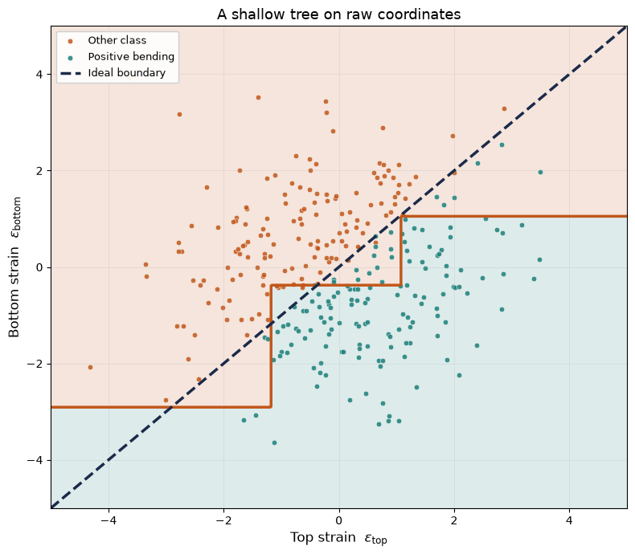

```python
clf.fit(X_raw, y)

# Grid over the raw plane
xx, yy = np.meshgrid(np.linspace(-lim, lim, 400),
                     np.linspace(-lim, lim, 400))
grid = np.c_[xx.ravel(), yy.ravel()]
Z = clf.predict(grid).reshape(xx.shape)

fig, ax = plt.subplots(figsize=(8, 7))

# Background: predicted class
ax.contourf(xx, yy, Z, levels=[-0.5, 0.5, 1.5],
            colors=[COLOR_B, COLOR_A], alpha=0.15)

# Data points
for cls, color, label in [(0, COLOR_B, 'Other class'),
                          (1, COLOR_A, 'Positive bending')]:
    mask = (y == cls)
    ax.scatter(top[mask], bottom[mask], c=color, s=22,
               alpha=0.85, label=label, edgecolors='white', linewidths=0.4)

# The tree's staircase boundary
ax.contour(xx, yy, Z, levels=[0.5], colors=[COLOR_B],
           linewidths=2.5, linestyles='-',
           )

# The ideal boundary
ax.plot([-lim, lim], [-lim, lim], '--', color=COLOR_LINE,
        linewidth=2.5, label='Ideal boundary')

ax.set_xlim(-lim, lim)
ax.set_ylim(-lim, lim)
ax.set_xlabel(r'Top strain  $\varepsilon_{\mathrm{top}}$', fontsize=12)
ax.set_ylabel(r'Bottom strain  $\varepsilon_{\mathrm{bottom}}$', fontsize=12)
ax.set_title('A shallow tree on raw coordinates', fontsize=13)
ax.legend(loc='upper left', framealpha=0.9, fontsize=9)
ax.grid(alpha=0.3)
plt.tight_layout()
plt.show()
```

Each raw axis mixes the two physical causes. The boundary we care about — the level set where bending is zero — is the **diagonal** $\varepsilon_{\text{top}} = \varepsilon_{\text{bottom}}$.

A decision tree splits along one coordinate at a time. It cuts horizontally or vertically. It cannot cut along the diagonal.

**The model's split directions and the physical direction differ.**

This is the geometry we will exploit in Section 3.

# Section 2 — The two representations

Mechanics tells us how to invert the mixture. The axial strain is the **average** of the two readings. The bending strain is their **difference**. Both are physical quantities with clear meaning.

```python
# The change of basis supplied by physics
axial_c   = (top + bottom) / 2
bending_c = (top - bottom) / 2

# Two representations of the same data
X_phys = np.c_[axial_c, bending_c]

print("X_raw shape: ", X_raw.shape)
print("X_phys shape:", X_phys.shape)
print("Labels shape:", y.shape)
```

```
X_raw shape:  (300, 2)
X_phys shape: (300, 2)
Labels shape: (300,)
```

```python
clf_phys = DecisionTreeClassifier(max_depth=3, random_state=0)

score_phys = cross_val_score(clf_phys, X_phys, y, cv=5).mean()

print(f"Physical coordinates: {score_phys:.3f}")
```

```
Physical coordinates: 0.977
```

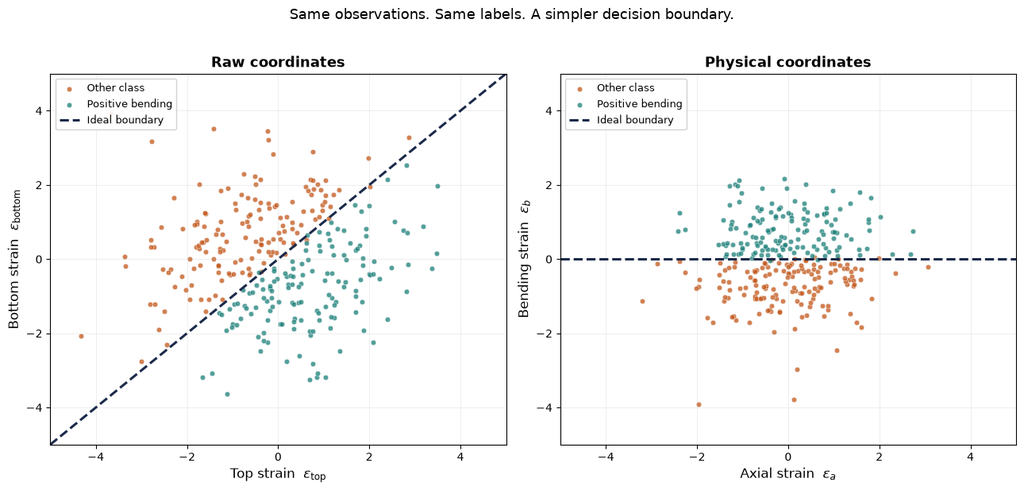

```python
# Side-by-side comparison
fig, axes = plt.subplots(1, 2, figsize=(13, 6))

# --- Left: raw coordinates ---
ax = axes[0]
for cls, color, label in [(0, COLOR_B, 'Other class'),
                          (1, COLOR_A, 'Positive bending')]:
    mask = (y == cls)
    ax.scatter(top[mask], bottom[mask], c=color, s=22,
               alpha=0.75, label=label, edgecolors='white', linewidths=0.4)
ax.plot([-lim, lim], [-lim, lim], '--', color=COLOR_LINE,
        linewidth=2.2, label='Ideal boundary')
ax.set_xlim(-lim, lim)
ax.set_ylim(-lim, lim)
ax.set_xlabel(r'Top strain  $\varepsilon_{\mathrm{top}}$', fontsize=12)
ax.set_ylabel(r'Bottom strain  $\varepsilon_{\mathrm{bottom}}$', fontsize=12)
ax.set_title('Raw coordinates', fontsize=13, fontweight='bold')
ax.legend(loc='upper left', framealpha=0.9, fontsize=9)
ax.grid(alpha=0.3)

# --- Right: physical coordinates ---
ax = axes[1]
for cls, color, label in [(0, COLOR_B, 'Other class'),
                          (1, COLOR_A, 'Positive bending')]:
    mask = (y == cls)
    ax.scatter(axial_c[mask], bending_c[mask], c=color, s=22,
               alpha=0.75, label=label, edgecolors='white', linewidths=0.4)
ax.axhline(0, linestyle='--', color=COLOR_LINE,
           linewidth=2.2, label='Ideal boundary')
ax.set_xlim(-lim, lim)
ax.set_ylim(-lim, lim)
ax.set_xlabel(r'Axial strain  $\varepsilon_a$', fontsize=12)
ax.set_ylabel(r'Bending strain  $\varepsilon_b$', fontsize=12)
ax.set_title('Physical coordinates', fontsize=13, fontweight='bold')
ax.legend(loc='upper left', framealpha=0.9, fontsize=9)
ax.grid(alpha=0.3)

plt.suptitle('Same observations. Same labels. A simpler decision boundary.',
             fontsize=13, y=1.02)
plt.tight_layout()
plt.show()
```

The observations have not changed. The labels have not changed. Only the input coordinates have changed.

In the physical representation, the boundary is a **single horizontal threshold** at $\varepsilon_b = 0$. In the raw representation, it is the **diagonal** $\varepsilon_{\text{top}} = \varepsilon_{\text{bottom}}$.

That difference is the entire session.

# Section 3 — The controlled comparison

We now train the **same classifier** on both representations. Same tree family, same depth limit, same random seed, same cross-validation. The only thing that changes is the input coordinate system.

```python
from sklearn.tree import DecisionTreeClassifier
from sklearn.model_selection import cross_val_score

clf = DecisionTreeClassifier(max_depth=3, random_state=0)

score_raw  = cross_val_score(clf, X_raw,  y, cv=5).mean()
score_phys = cross_val_score(clf, X_phys, y, cv=5).mean()

print(f"Raw coordinates:      {score_raw:.3f}")
print(f"Physical coordinates: {score_phys:.3f}")
```

```
Raw coordinates:      0.867
Physical coordinates: 0.977
```

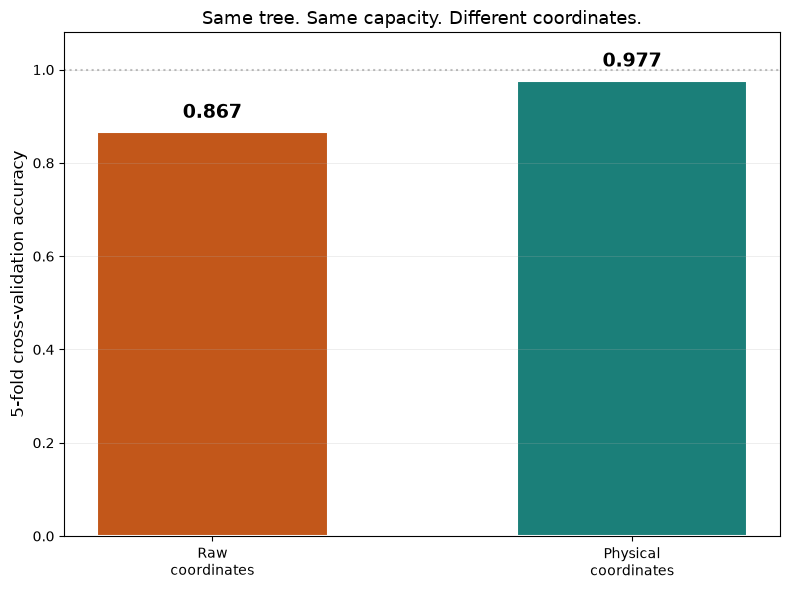

```python
fig, ax = plt.subplots(figsize=(8, 6))

values = [score_raw, score_phys]
labels = ['Raw\ncoordinates', 'Physical\ncoordinates']
colors = [COLOR_B, COLOR_A]

bars = ax.bar(labels, values, color=colors, width=0.55,
              edgecolor='white', linewidth=1.5)

for bar, v in zip(bars, values):
    ax.text(bar.get_x() + bar.get_width() / 2, v + 0.02,
            f"{v:.3f}", ha='center', va='bottom',
            fontsize=14, fontweight='bold')

ax.set_ylim(0, 1.08)
ax.set_ylabel('5-fold cross-validation accuracy', fontsize=12)
ax.set_title('Same tree. Same capacity. Different coordinates.',
             fontsize=13)
ax.axhline(1.0, linestyle=':', color='gray', alpha=0.5)
ax.grid(alpha=0.3, axis='y')
plt.tight_layout()
plt.show()
```

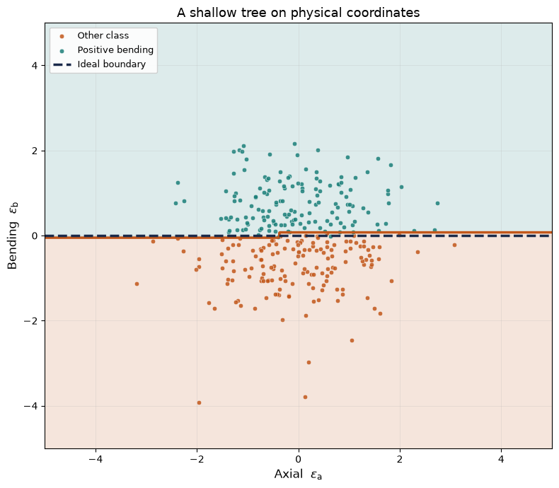

```python
# Fit the shallow tree on raw coordinates for the plot
tree_raw = DecisionTreeClassifier(max_depth=3, random_state=0)
tree_raw.fit(X_phys, y)

# Grid over the raw plane
xx, yy = np.meshgrid(np.linspace(-lim, lim, 400),
                     np.linspace(-lim, lim, 400))
grid = np.c_[xx.ravel(), yy.ravel()]
Z = tree_raw.predict(grid).reshape(xx.shape)

fig, ax = plt.subplots(figsize=(8, 7))

# Background: predicted class
ax.contourf(xx, yy, Z, levels=[-0.5, 0.5, 1.5],
            colors=[COLOR_B, COLOR_A], alpha=0.15)

# Data points
for cls, color, label in [(0, COLOR_B, 'Other class'),
                          (1, COLOR_A, 'Positive bending')]:
    mask = (y == cls)
    ax.scatter(axial_c[mask], bending_c[mask], c=color, s=22,
               alpha=0.85, label=label, edgecolors='white', linewidths=0.4)

# The tree's staircase boundary
ax.contour(xx, yy, Z, levels=[0.5], colors=[COLOR_B],
           linewidths=2.5, linestyles='-',
           )

# The ideal boundary
ax.plot([-lim, lim], [-0, 0], '--', color=COLOR_LINE,
        linewidth=2.5, label='Ideal boundary')

ax.set_xlim(-lim, lim)
ax.set_ylim(-lim, lim)
ax.set_xlabel(r'Axial  $\varepsilon_{\mathrm{a}}$', fontsize=12)
ax.set_ylabel(r'Bending  $\varepsilon_{\mathrm{b}}$', fontsize=12)
ax.set_title('A shallow tree on physical coordinates', fontsize=13)
ax.legend(loc='upper left', framealpha=0.9, fontsize=9)
ax.grid(alpha=0.3)
plt.tight_layout()
plt.show()
```

**The model is not stupid. The coordinates are stupid.**

# Section 4 — Do deeper trees fix this?

A natural objection: *a shallow tree cannot fit the diagonal, but a deep tree can.* This is true. And it is not the point.

A deep tree can approximate the diagonal arbitrarily well by adding more staircase steps. What it cannot do is **extrapolate**. Let us see why.

```python
# Train a deep tree on raw coordinates
tree_deep = DecisionTreeClassifier(max_depth=None, random_state=0)
tree_deep.fit(X_raw, y)

train_acc = tree_deep.score(X_raw, y)

print(f"Deep tree training accuracy: {train_acc:.4f}")
print(f"Number of leaves: {tree_deep.get_n_leaves()}")
```

```
Deep tree training accuracy: 1.0000
Number of leaves: 22
```

[figure not shown]

```python
# The deep tree's decision boundary
Z_deep = tree_deep.predict(grid).reshape(xx.shape)

fig, axes = plt.subplots(1, 2, figsize=(14, 6.5))

for ax, Z, title in [(axes[0], Z, 'Shallow tree (depth 3)'),
                     (axes[1], Z_deep, 'Deep tree (unlimited depth)')]:
    ax.contourf(xx, yy, Z, levels=[-0.5, 0.5, 1.5],
                colors=[COLOR_B, COLOR_A], alpha=0.15)
    for cls, color in [(0, COLOR_B), (1, COLOR_A)]:
        mask = (y == cls)
        ax.scatter(top[mask], bottom[mask], c=color, s=15,
                   alpha=0.7, edgecolors='white', linewidths=0.3)
    ax.contour(xx, yy, Z, levels=[0.5], colors=[COLOR_B],
               linewidths=2.0)
    ax.plot([-lim, lim], [-lim, lim], '--', color=COLOR_LINE,
            linewidth=2.0)
    ax.set_xlim(-lim, lim)
    ax.set_ylim(-lim, lim)
    ax.set_xlabel(r'$\varepsilon_{\mathrm{top}}$', fontsize=12)
    ax.set_ylabel(r'$\varepsilon_{\mathrm{bottom}}$', fontsize=12)
    ax.set_title(title, fontsize=12, fontweight='bold')
    ax.grid(alpha=0.3)

plt.suptitle('More splits approximate the diagonal, but the boundary is still a staircase.',
             fontsize=12, y=1.01)
plt.tight_layout()
plt.show()
```

Now the failure. Outside the training range, the deep tree has no staircase steps. It simply extends the last box it saw. Let us ask it what happens at input points far outside the training data.

```python
# Query points far outside the training region
# Format: (top, bottom, true class based on physics)
queries = [
    ( 6.0,  6.0, 0),   # bending = 0    → boundary, true class 0
    ( 6.0,  2.0, 1),   # bending = 2    → positive bending
    ( 2.0,  6.0, 0),   # bending = -2   → negative bending
    ( 6.0,  5.0, 1),   # bending = 0.5  → positive bending
    (-6.0, -5.0, 0),   # bending = -0.5 → negative bending
    ( 5.0, -1.0, 1),   # bending = 3    → positive bending
    (-1.0,  5.0, 0),   # bending = -3   → negative bending
]

print(f"{'Query (top, bottom)':22s}  {'True bending':>12s}  {'True class':>10s}  "
      f"{'Shallow pred':>12s}  {'Deep pred':>10s}")
print("-" * 80)
for top_q, bot_q, true_cls in queries:
    true_bend = (top_q - bot_q) / 2
    pred_shallow = tree_raw.predict([[top_q, bot_q]])[0]
    pred_deep    = tree_deep.predict([[top_q, bot_q]])[0]
    flag_shallow = '✓' if pred_shallow == true_cls else '✗'
    flag_deep    = '✓' if pred_deep == true_cls else '✗'
    print(f"({top_q:+5.1f}, {bot_q:+5.1f})         "
          f"{true_bend:+12.2f}  {true_cls:>10d}  "
          f"{pred_shallow:>10d} {flag_shallow}  "
          f"{pred_deep:>8d} {flag_deep}")
```

```
Query (top, bottom)     True bending  True class  Shallow pred   Deep pred
--------------------------------------------------------------------------------
( +6.0,  +6.0)                +0.00           0           1 ✗         0 ✓
( +6.0,  +2.0)                +2.00           1           1 ✓         1 ✓
( +2.0,  +6.0)                -2.00           0           1 ✗         0 ✓
( +6.0,  +5.0)                +0.50           1           1 ✓         0 ✗
( -6.0,  -5.0)                -0.50           0           0 ✓         1 ✗
( +5.0,  -1.0)                +3.00           1           0 ✗         1 ✓
( -1.0,  +5.0)                -3.00           0           1 ✗         0 ✓
```

Read the last column carefully. The deep tree is confident everywhere. It has no way to signal that it has left the region where it was trained. It extends its last box indefinitely, and the prediction it returns is arbitrary.

**This is the silent failure the cheap habit cannot see.** Training accuracy was near 1.0. Cross-validation was high. And yet, one step outside the training distribution, the model is wrong with the same confidence as when it was right.

A deep tree can fit the diagonal. It cannot extrapolate it. The failure is representational, not algorithmic. The right coordinates remove the need for extrapolation because the boundary is no longer a diagonal — it is a threshold the model was trained on directly.

**This is why the session is about representation, not model capacity.**

# Section 5 — Summary

The cantilever has shown the same root cause as the projectile, through a different mechanism.

- The projectile's **hypothesis class** could not express the shape.
- The cantilever's **coordinates** mixed the causes.

In both cases the fix was to change the representation. In both cases no amount of data or tuning could have saved the original setup. In both cases the right representation came from prior knowledge, not from the data.

**The question we leave with:** *what happens when we do not know the physics?*

This is the subject of Session 2.

# Bonus — Can we discover the coordinates from data alone?

In both sessions so far, the right representation came from physics. A natural question: **can we recover it from the data, without the physics?**

The next session will answer.